# Control DE

Barry Digby

30/11/2018

# Report Outline:

This report is on Differential Expression (DE) between S2 and WT samples in the Control samples. # Stringtie to DESeq2 object:

```r
library(DESeq2)
library(tximport)

directory <- "/Users/barrydigby/Desktop/read_tables/"

data <- c("/Users/barrydigby/Desktop/read_tables/H84S2Ctrl_S7/t_data.ctab",
          "/Users/barrydigby/Desktop/read_tables/H84WTCtrl_S1/t_data.ctab",
          "/Users/barrydigby/Desktop/read_tables/H85S2Ctrl_S8/t_data.ctab",
          "/Users/barrydigby/Desktop/read_tables/H85WTCtrl_S2/t_data.ctab",
          "/Users/barrydigby/Desktop/read_tables/H86S2Ctrl_S9/t_data.ctab",
          "/Users/barrydigby/Desktop/read_tables/H86WTCtrl_S3/t_data.ctab")

tmp <- read.table(data[1], header = TRUE)
names(data) <- c("S2Ctrl_7", "WTCtrl_1", "S2Ctrl_8", "WTCtrl_2", "S2Ctrl_9", "WTCtrl_3")
tx2gene <- tmp[, c("t_name", "gene_name")]
txi <- tximport(data, type = "stringtie", tx2gene = tx2gene)
```

```
## reading in files with read_tsv
```

```
## 1 2 3 4 5 6
## summarizing abundance
## summarizing counts
## summarizing length
```

```r
sampleNames <- c("S2Ctrl_7", "WTCtrl_1", "S2Ctrl_8", "WTCtrl_2", "S2Ctrl_9", "WTCtrl_3")
sampleGroup <- c("S2", "WT", "S2", "WT", "S2", "WT")
sampleTable <- data.frame(sampleName = sampleNames, type = sampleGroup)


rownames(sampleTable) <- colnames(txi$counts)
ddsTxi <- DESeqDataSetFromTximport(txi, sampleTable, design = ~ type)
```

```
## using counts and average transcript lengths from tximport
```

```r
dds <- DESeq(ddsTxi)
```

```
## using 'avgTxLength' from assays(dds), correcting for library size
```

```r
res <- results(dds)
counts <- counts(dds)
```

# Data Quality Assessment

### Transformation & Visualization

The majority of genes have zero or very low counts, thus we apply a log2-transformation on counts before visualization. The distribution of log2 transformed counts are shown as a boxplot and a density plot:

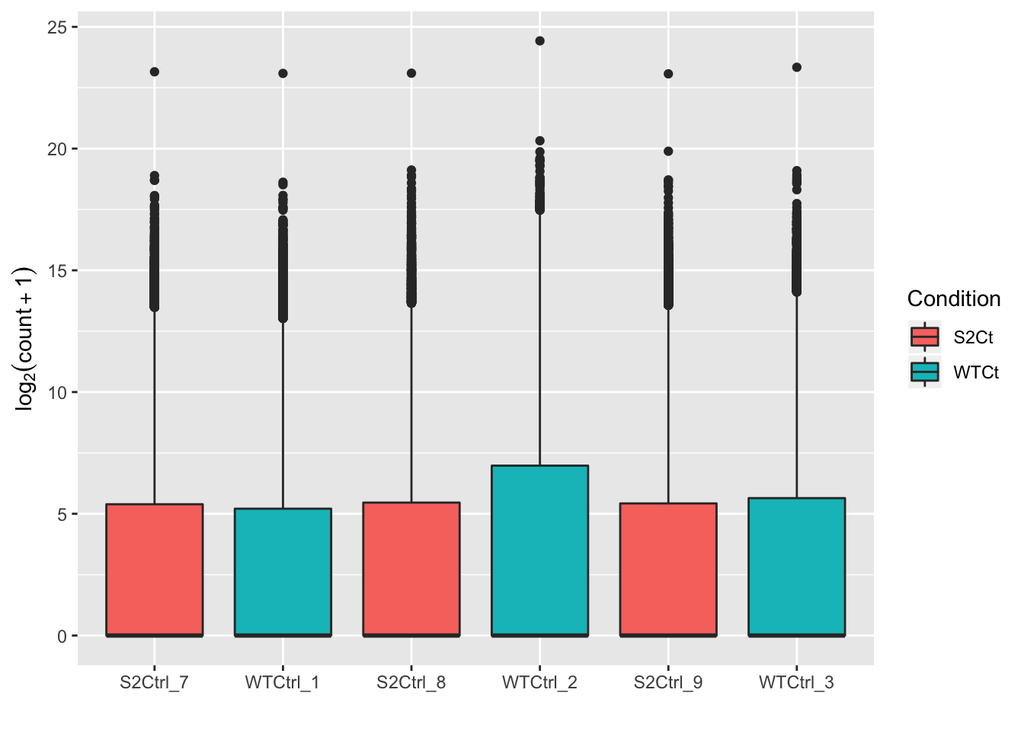

```r
pseudoCount = log2(counts + 1)

library(reshape2)
library(ggplot2)
pseudoCount = as.data.frame(pseudoCount)
df = melt(pseudoCount, variable.name = "Samples", value.name = "count") # reshape the matrix
df = data.frame(df, Condition = substr(df$Samples, 1, 4))
ggplot(df, aes(x = df$Samples, y = count, fill = Condition)) + geom_boxplot() + xlab("") +
  ylab(expression(log[2](count + 1)))
```

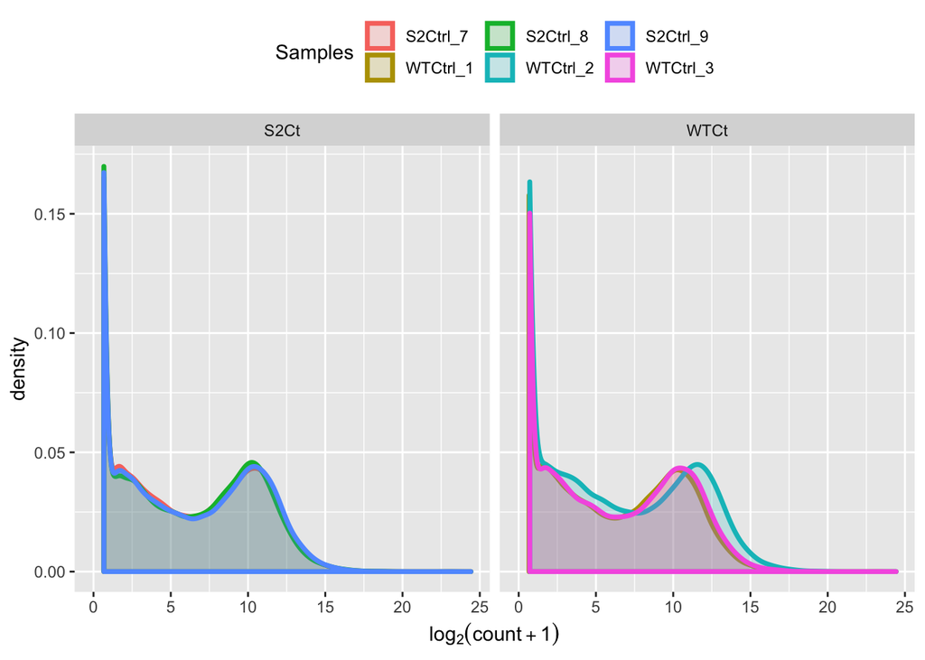

```r
ggplot(df, aes(x = count, colour = Samples, fill = Samples)) + ylim(c(0, 0.17)) +
  geom_density(alpha = 0.2, size = 1.25) + facet_wrap(~ Condition) +
  theme(legend.position = "top") + xlab(expression(log[2](count + 1)))
```

# Sample to Sample Distances

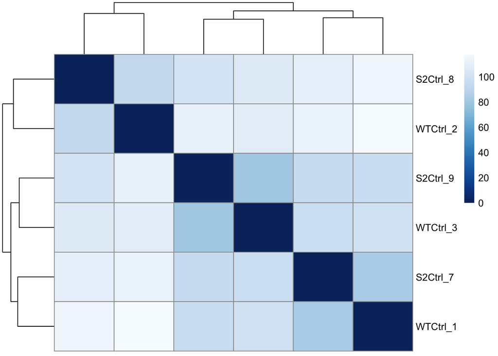

```r
sampleDists <- dist(t(assay(vsd)))
library("pheatmap")
library("RColorBrewer")
sampleDistMatrix <- as.matrix(sampleDists)
rownames(sampleDistMatrix) <- vsd$sampleName
colnames(sampleDistMatrix) <- NULL
colors <- colorRampPalette( rev(brewer.pal(9, "Blues")) )(255)
pheatmap(sampleDistMatrix,
         clustering_distance_rows=sampleDists,
         clustering_distance_cols=sampleDists,
         col=colors)
```

# PCA plots

```r
library(mixOmics)
```

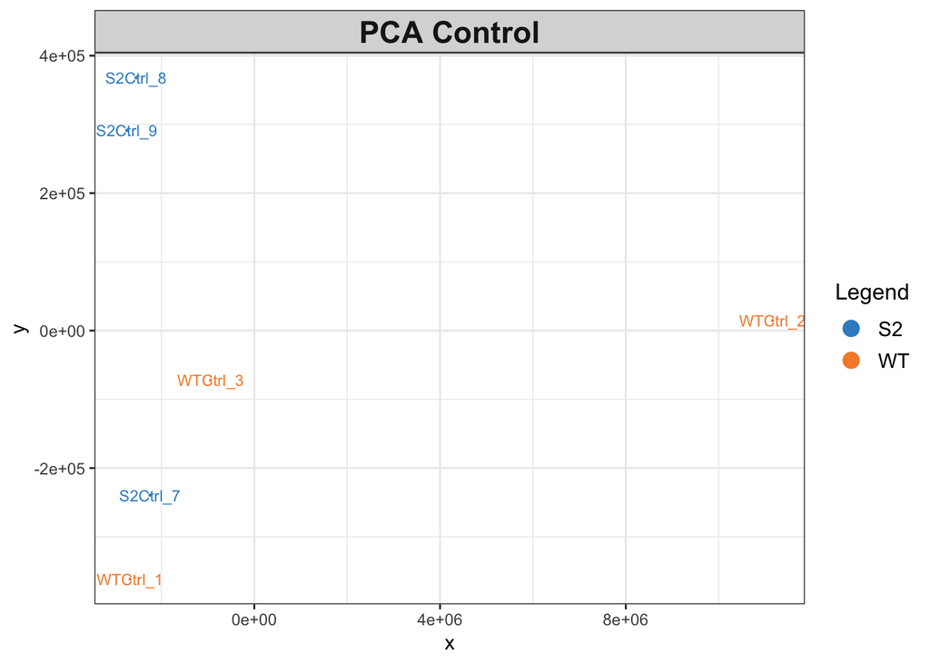

```r
counts.t <- t(counts(dds))
outcome <- as.factor(dds$type)

pca = pca(counts.t, ncomp = 6)
plotIndiv(pca, group = outcome, ind.names = TRUE, legend = TRUE, title = 'PCA Control')
```

```r
plsda_ <- plsda(counts.t, outcome, ncomp = 5)
```

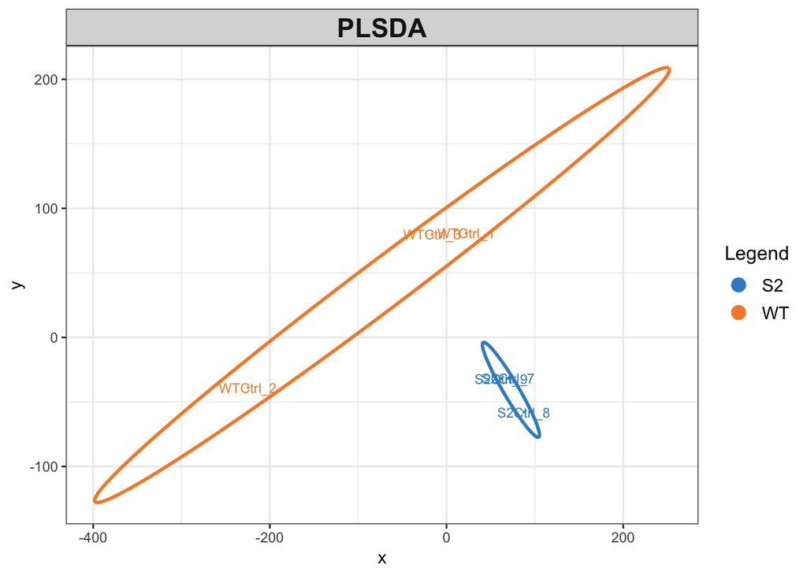

```r
plotIndiv(plsda_, comp = 1:2, group = outcome, ind.names = TRUE, ellipse = TRUE, legend = TRUE, title = 'PLSDA')
```

# Systematic biases

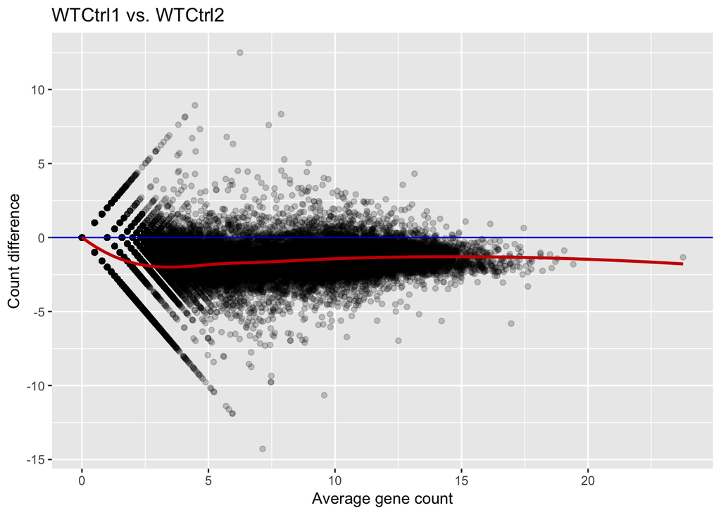

```r
x = pseudoCount[, 2] #
y = pseudoCount[, 4]
M = x - y # M-values (differences between samples)
A = (x + y)/2 # A-values (averages)
df = data.frame(A, M)
ggplot(df, aes(x = A, y = M)) + geom_point(size = 1.5, alpha = 1/5) +
geom_hline(aes(yintercept = 0), color = "blue3") + stat_smooth(se =
FALSE, method = "loess", color = "red3") +
  xlab("Average gene count") +
  ylab("Count difference") +
  ggtitle("WTCtrl1 vs. WTCtrl2")
```

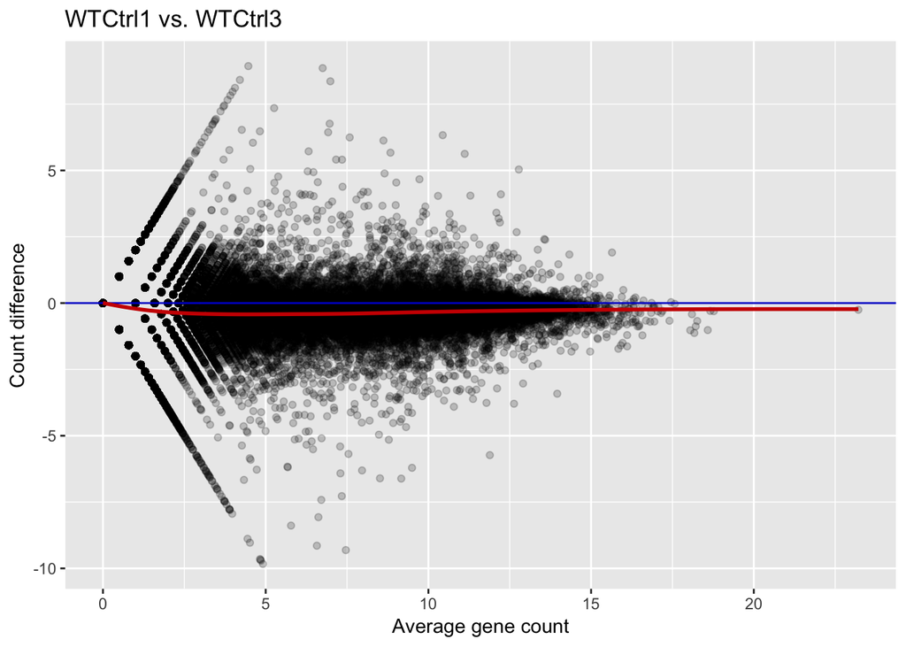

```r
x = pseudoCount[, 2] #
y = pseudoCount[, 6] #
M = x - y # M-values (differences between samples)
A = (x + y)/2 # A-values (averages)
df = data.frame(A, M)
ggplot(df, aes(x = A, y = M)) + geom_point(size = 1.5, alpha = 1/5) +
geom_hline(aes(yintercept = 0), color = "blue3") + stat_smooth(se =
FALSE, method = "loess", color = "red3") +
  xlab("Average gene count") +
  ylab("Count difference") +
  ggtitle("WTCtrl1 vs. WTCtrl3")
```

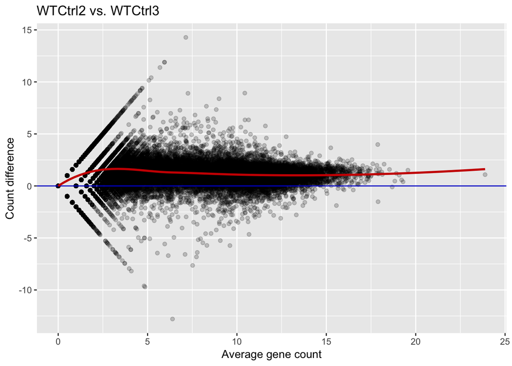

```r
x = pseudoCount[, 4] # e
y = pseudoCount[, 6] #
M = x - y # M-values (differences between samples)
A = (x + y)/2 # A-values (averages)
df = data.frame(A, M)
ggplot(df, aes(x = A, y = M)) + geom_point(size = 1.5, alpha = 1/5) +
geom_hline(aes(yintercept = 0), color = "blue3") + stat_smooth(se =
FALSE, method = "loess", color = "red3") +
  xlab("Average gene count") +
  ylab("Count difference") +
  ggtitle("WTCtrl2 vs. WTCtrl3")
```

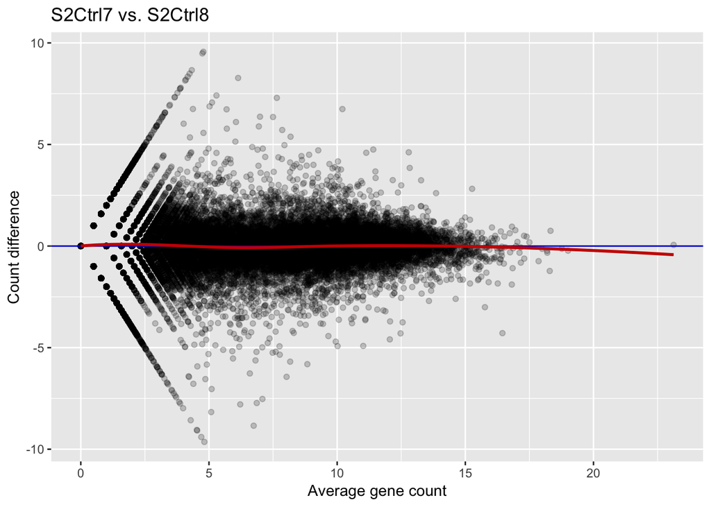

```r
x = pseudoCount[, 1]
y = pseudoCount[, 3]
M = x - y # M-values (differences between samples)
A = (x + y)/2 # A-values (averages)
df = data.frame(A, M)
ggplot(df, aes(x = A, y = M)) + geom_point(size = 1.5, alpha = 1/5) +
geom_hline(aes(yintercept = 0), color = "blue3") + stat_smooth(se =
FALSE, method = "loess", color = "red3") +
  xlab("Average gene count") +
  ylab("Count difference") +
  ggtitle("S2Ctrl7 vs. S2Ctrl8")
```

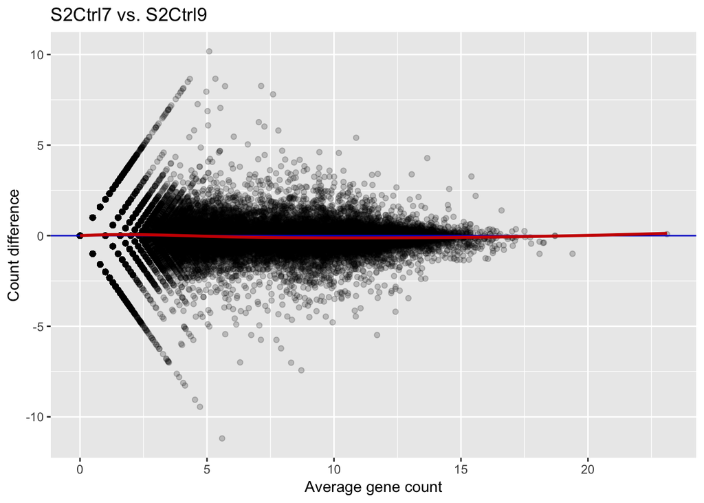

```r
x = pseudoCount[, 1]
y = pseudoCount[, 5]
M = x - y # M-values (differences between samples)
A = (x + y)/2 # A-values (averages)
df = data.frame(A, M)
ggplot(df, aes(x = A, y = M)) + geom_point(size = 1.5, alpha = 1/5) +
geom_hline(aes(yintercept = 0), color = "blue3") + stat_smooth(se =
FALSE, method = "loess", color = "red3") +
  xlab("Average gene count") +
  ylab("Count difference") +
  ggtitle("S2Ctrl7 vs. S2Ctrl9")
```

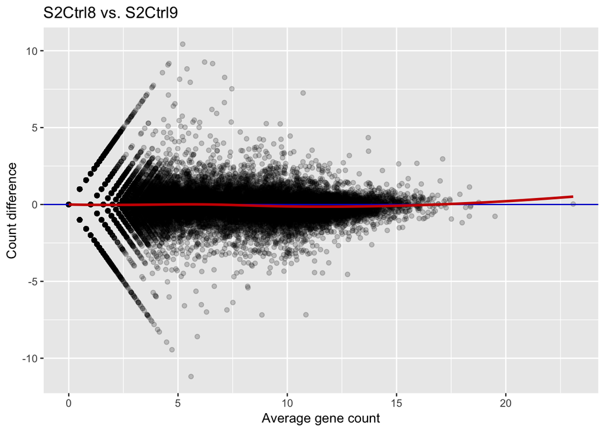

```r
x = pseudoCount[, 3]
y = pseudoCount[, 5]
M = x - y # M-values (differences between samples)
A = (x + y)/2 # A-values (averages)
df = data.frame(A, M)
ggplot(df, aes(x = A, y = M)) + geom_point(size = 1.5, alpha = 1/5) +
geom_hline(aes(yintercept = 0), color = "blue3") + stat_smooth(se =
FALSE, method = "loess", color = "red3") +
  xlab("Average gene count") +
  ylab("Count difference") +
  ggtitle("S2Ctrl8 vs. S2Ctrl9")
```

# Differential expression analysis

```r
summary(res)
```

```
##
## out of 30845 with nonzero total read count
## adjusted p-value < 0.1
## LFC > 0 (up)       : 22, 0.071%
## LFC < 0 (down)     : 16, 0.052%
## outliers [1]       : 117, 0.38%
## low counts [2]     : 9138, 30%
## (mean count < 3)
## [1] see 'cooksCutoff' argument of ?results
## [2] see 'independentFiltering' argument of ?results
```

# MA Plot

Red points have adjusted p value < 0.1. We can see a lot of noise, using a shrunken log2 fold change reduces the noise.

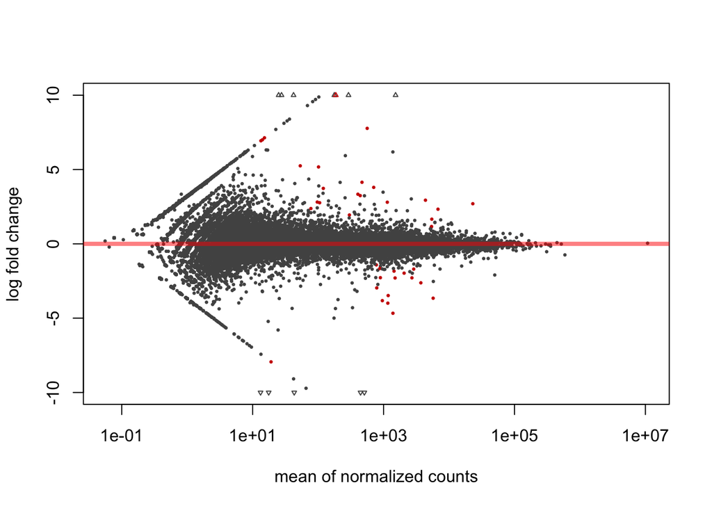

```r
plotMA(res, ylim=c(-10,10))
```

```r
resShrink = lfcShrink(dds, coef=2)
```

```
## using 'normal' for LFC shrinkage, the Normal prior from Love et al (2014).
## additional priors are available via the 'type' argument, see ?lfcShrink for details
```

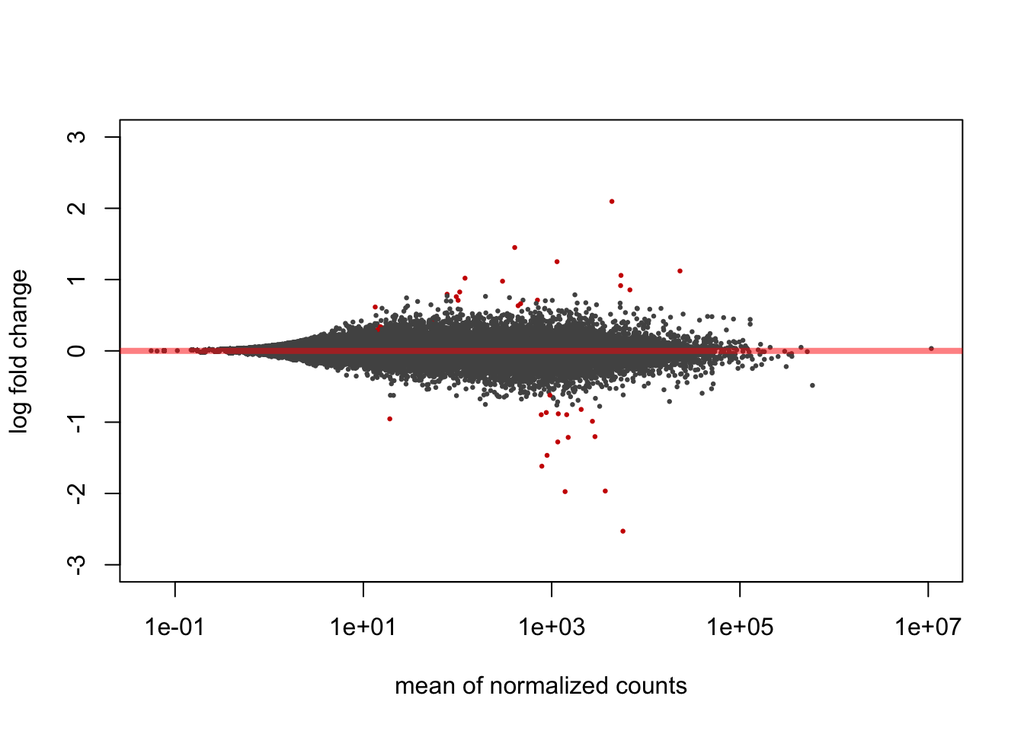

```r
plotMA(resShrink, ylim=c(-3,3))
```

# Extract Significant genes: P value = 0.05 = 544 genes Adj P value = 0.1 = 38 genes Both write to csv ..

```r
resOrdered <- res[order(res$pvalue),]

pvalue <- subset(resOrdered, pvalue < 0.05)

write.csv(pvalue, file="Control_0.05_Pvalue.csv")

padj <- subset(resOrdered, padj < 0.1)

write.csv(padj, file="Control_0.1_Padj.csv")
```